# The Behavioralist Visits the Factory

Fall 2017

## Story so far?

*How* a decision is presented affects people's actions

- endowment effect
- status quo bias
- WTP \(\neq\) WTA
- loss aversion

Lots of evidence from the laboratory, less from the "field".

Also, less evidence (though some) from "economically relevant" decisions.

## What do haters say?

These phenomena are explained by…

- bad experimental design
- people who don't or haven't had time to learn

## Enter Hossain & List

- Data from a natural field experiment at Wanlida Group.
- Wanlida \(\Rightarrow\) top 100 electronics manufacturers

[figure not shown]

## Treatments

- "Reward/Gain": "positive frame" – if the week's average per-hour production *reaches* a threshold, a *bonus* is paid at the end of the pay period. Weekly bonus = RMB 80.
- "Punishment/Loss": "negative frame" – employees *provisionally given* the bonus *before* the week begins, if the week's average per-hour production *fails to reach* a threshold, the *bonus* is taken away at the end of the pay period. Weekly bonus = RMB 80.
- "Gift": just a control (also company wanted it): one-time four-week bonus of RMB 320

## Main Results

1. Bonuses (of either type) increase productivity for groups and individuals.
2. Punishment/Loss frame outperforms the gain frame for groups and individuals (less robust) \(\Rightarrow\) an \(\uparrow\) of 1% of production (this is economically significant) at low marginal cost
3. Effects are stronger for groups than individuals.
4. Effects persist for whole period of study (long-term).

## Implications and Significance

1. Incentives are powerful & behavioral econ has a role in the workplace.
2. Results complement industrial psch & expand toolset of practitioners.
3. Social structure & institutions affect/constrain how people act in the workplace.

## Institutional Detail

- Teams of workers (14 people) engaged in relatively flexible production
- Individual inspectors (of products) involved in incentive schemes too
- Can compare pre- and post-experiment:
  - *productivity* in terms of output (DVD chips)
  - *quality* of productivity with error rate
- 4 weeks in a treatment; 1 week after a treatment ended

## Additional desing issues

- all payments made to all teams at the same time
  - improves credibility
  - limits time preference concerns
- compare *within* and *between* observations
  - same observation exposed to multiple treatments
- workers didn't know about experiment
- management wanted targets achieved in 60-80% of cases (morale)
  - targets calibrated with pre-experiment data
- minimized information transmission between groups

## Overall productivity

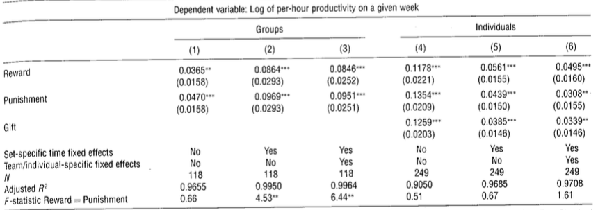

## Defect rate

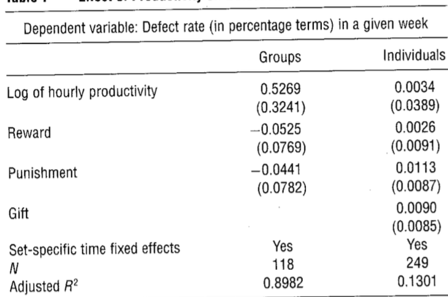

## Group effects over time

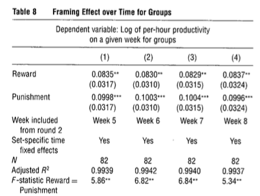

## Individual effect over time

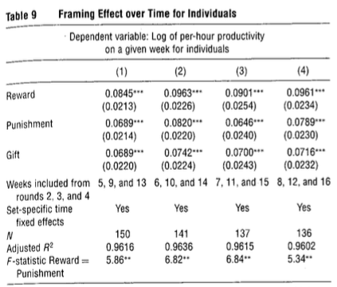

## Discussion & Conclusion

- Find strong treatment effects among teams of workers
- Stronger effect for teams than individuals means how groups are formed is important: "collective esteem" in a group; "group polarization";
  - people are worried about letting team members down
  - workers in loss frame may be extra careful not to cost the team the bonus
  - large groups more likely to contain a very loss averse person

## Profitability

- Where incentives *profitable* for the firm? Yes!
  - Quality rate remained constant
  - Cost of incentives: RMB 64,960;
  - To hire more workers for same output would have cost about RMB 69,900
- What about permanently adopting the bonuses/penalties?
  - long-run effects of incentives
  - no 'trend' in the effects; remain constant throughout study

Take home messsage: Behavioral econ can play a big role in improving productivity and profitability within firms.